# Exploration of SEC62 and HLA-E in DLBCL tumors

Rendered 01/09/2026

Author

Jeremy M. Simon

# Set up workspace

```r
library(tidyverse)
library(readxl)
library(patchwork)
library(ggpubr)
library(grid)
library(ComplexHeatmap)
library(circlize)
library(patchwork)
```

# Import patient metadata from Supplementary Table S9

```r
meta <- read_excel("/tcga-artemis/tcga_DLBCL_APRIL_2018/tcga_DLBCL_APRIL_2018_OPEN-ACCESS_FILES/529be438-e42c-4725-a3f3-66f6fd42ffae/Supplementary_Appendix_2.xlsx", sheet=9) %>%
    dplyr::filter(!is.na(Diagnosis))
meta
```

```
# A tibble: 574 × 20
   dbGaP submitted subject …¹ `dbGaP accession` Diagnosis Gene Expression Subg…²
   <chr>                      <chr>             <chr>     <chr>
 1 DLBCL11202                 phs001444         Diffuse … Unclass
 2 DLBCL10484                 phs001444         Diffuse … GCB
 3 DLBCL10555                 phs001444         Diffuse … GCB
 4 DLBCL10942                 phs001444         Diffuse … Unclass
 5 DLBCL10566                 phs001444         Diffuse … Unclass
 6 DLBCL10549                 phs001444         Diffuse … GCB
 7 DLBCL11191                 phs001444         Diffuse … Unclass
 8 DLBCL11541                 phs001444         Diffuse … GCB
 9 DLBCL11660                 phs001444         Diffuse … GCB
10 DLBCL11503                 phs001444         Diffuse … ABC
# ℹ 564 more rows
# ℹ abbreviated names: ¹`dbGaP submitted subject ID`,
#   ²`Gene Expression Subgroup`
# ℹ 16 more variables: `Genetic Subtype` <chr>, `Biopsy Type` <chr>,
#   Treatment__ <chr>, Gender <chr>, Age <dbl>, `Ann Arbor Stage` <dbl>,
#   `LDH Ratio` <dbl>, `ECOG Performance Status` <dbl>,
#   `Number of Extranodal Sites` <dbl>, `IPI Group` <chr>, `IPI Range` <dbl>, …
```

# Gather expression and genetic subtype info

```r
subtypes <- meta %>%
    dplyr::select(`dbGaP submitted subject ID`,
                  `Gene Expression Subgroup`,
                  `Genetic Subtype`) %>%
    dplyr::rename("ID" = `dbGaP submitted subject ID`,
                  "ExpressionSubtype" = `Gene Expression Subgroup`,
                  "GeneticSubtype" = `Genetic Subtype`
)
subtypes
```

```
# A tibble: 574 × 3
   ID         ExpressionSubtype GeneticSubtype
   <chr>      <chr>             <chr>
 1 DLBCL11202 Unclass           Other
 2 DLBCL10484 GCB               Other
 3 DLBCL10555 GCB               EZB
 4 DLBCL10942 Unclass           BN2
 5 DLBCL10566 Unclass           Other
 6 DLBCL10549 GCB               Other
 7 DLBCL11191 Unclass           BN2
 8 DLBCL11541 GCB               Other
 9 DLBCL11660 GCB               BN2
10 DLBCL11503 ABC               N1
# ℹ 564 more rows
```

# Import gene expression matrix

This is for all 562 patients

```r
expr <- read_tsv("/tcga-artemis/tcga_DLBCL_APRIL_2018/tcga_DLBCL_APRIL_2018_OPEN-ACCESS_FILES/894155a9-b039-4d50-966c-997b0e2efbc2/RNAseq_gene_expression_562.txt", guess_max=50000) %>%
    dplyr::select(-Accession,-Gene_ID) %>%
    pivot_longer(cols = !Gene, names_to="ID", values_to="Expression")
expr
```

```
# A tibble: 14,087,092 × 3
   Gene  ID         Expression
   <chr> <chr>           <dbl>
 1 A1BG  CTSP-ACZT        8.33
 2 A1BG  CTSP-ACZU        7.15
 3 A1BG  CTSP-ACZW        8.94
 4 A1BG  CTSP-AD2E        8.64
 5 A1BG  CTSP-B02B        8.09
 6 A1BG  DLBCL10502       9.20
 7 A1BG  DLBCL10521       8.80
 8 A1BG  CTSP-ACY5        9.07
 9 A1BG  CTSP-ACY6        9.9
10 A1BG  CTSP-ACY8        9.97
# ℹ 14,087,082 more rows
```

# Import and tidy CNV data by gene

These data are split by individual cohort, each protected access only so no previews given here

```r
ctsp_gene_cnv <- read_tsv("/tcga-artemis/tcga_DLBCL_APRIL_2018/ctsp_DLBCL_APRIL_2018_CTRL-ACCESS_FILES/b292ed1e-191d-4eab-8bb5-1441423842bb/CopyNumber_Summary_45_CTSP-DLBCL1_phs001184/CopyNumber_Gene_45_CTSP-DLBCL1_phs001184.txt")
nciccr_gene_cnv <- read_tsv("/tcga-artemis/tcga_DLBCL_APRIL_2018/nciccr_DLBCL_APRIL_2018_CTRL-ACCESS_FILES/64b783ce-db58-4584-af16-98e4a909c756/CopyNumber_Summary_476_NCICCR-DLBCL_phs001444/CopyNumber_Gene_476_NCICCR-DLBCL_phs001444.txt")
tcga_gene_cnv <- read_tsv("/tcga-artemis/tcga_DLBCL_APRIL_2018/tcga_DLBCL_APRIL_2018_CTRL-ACCESS_FILES/c1f2ed0d-6d3f-417f-a374-6dcfed351406/CopyNumber_Summary_39_TCGA-DLBC_phs000178/CopyNumber_Gene_39_TCGA-DLBC_phs000178.txt")
```

# Import and tidy SNV data for HLA genes

These data are split by individual cohort, each protected access only

```r
ctsp_snv <- read_tsv("/tcga-artemis/tcga_DLBCL_APRIL_2018/ctsp_DLBCL_APRIL_2018_CTRL-ACCESS_FILES/e5455577-906c-4cb0-9d07-70de3dfe89a1/MAF_CTSP-DLBCL1_phs001184.txt")
nciccr_snv <- read_tsv("/tcga-artemis/tcga_DLBCL_APRIL_2018/nciccr_DLBCL_APRIL_2018_CTRL-ACCESS_FILES/f0325846-10a5-46b9-984d-c93a473bb6a4/MAF_NCICCR-DLBCL_phs001444.txt")
tcga_snv <- read_tsv("/tcga-artemis/tcga_DLBCL_APRIL_2018/tcga_DLBCL_APRIL_2018_CTRL-ACCESS_FILES/7156a0a2-4df1-446f-a8cd-31df5b121e74/MAF_TCGA-DLBC_phs000178.txt")
hla_snvs <- bind_rows(bind_rows(ctsp_snv,nciccr_snv),tcga_snv) %>%
    dplyr::rename("Gene_Symbol" = `GENE SYMBOL`) %>%
  dplyr::filter(str_detect(Gene_Symbol, "^HLA-")) %>%
  dplyr::select(SUBJECT_NAME,Gene_Symbol,MUTATION_TYPE) %>%
  group_by(SUBJECT_NAME,Gene_Symbol) %>%
  summarize(SNVs = str_c(MUTATION_TYPE, collapse = ",")) %>%
  ungroup() %>%
  right_join(.,expand_grid("SUBJECT_NAME" = meta$`dbGaP submitted subject ID`,
            "Gene_Symbol" = c("HLA-A","HLA-B","HLA-C","HLA-E","HLA-F","HLA-G")
      ),
      by=c("SUBJECT_NAME","Gene_Symbol")
  ) %>%
  mutate(HLA_SNV = case_when(
    !is.na(SNVs) ~ "SNV",
    TRUE ~ SNVs
    )
  ) %>%
  dplyr::select(-SNVs) %>%
  dplyr::rename("ID" = SUBJECT_NAME)
```

# Summarize SEC62 copy number

```r
sec62_cnv <- bind_rows(bind_rows(ctsp_gene_cnv,nciccr_gene_cnv),tcga_gene_cnv) %>%
    dplyr::filter(Gene_Symbol == "SEC62") %>%
    dplyr::select(Subject_Name,CopyNubmer_Status) %>%
    dplyr::rename("SEC62_CopyNumber" = CopyNubmer_Status) %>%
    left_join(meta, ., by=c("dbGaP submitted subject ID" = "Subject_Name")) %>%
    dplyr::select(`dbGaP submitted subject ID`,SEC62_CopyNumber) %>%
    dplyr::rename("ID" = `dbGaP submitted subject ID`) %>%
    mutate(SEC62_CopyNumber = case_when(
        is.na(SEC62_CopyNumber) ~ "WT",
        (SEC62_CopyNumber == "GAIN") | (SEC62_CopyNumber == "AMP") ~ "GAIN",
        TRUE ~ SEC62_CopyNumber
        )
    )
```

# Plot HLA-E vs SEC62 expression grouped and colored by expression subtype

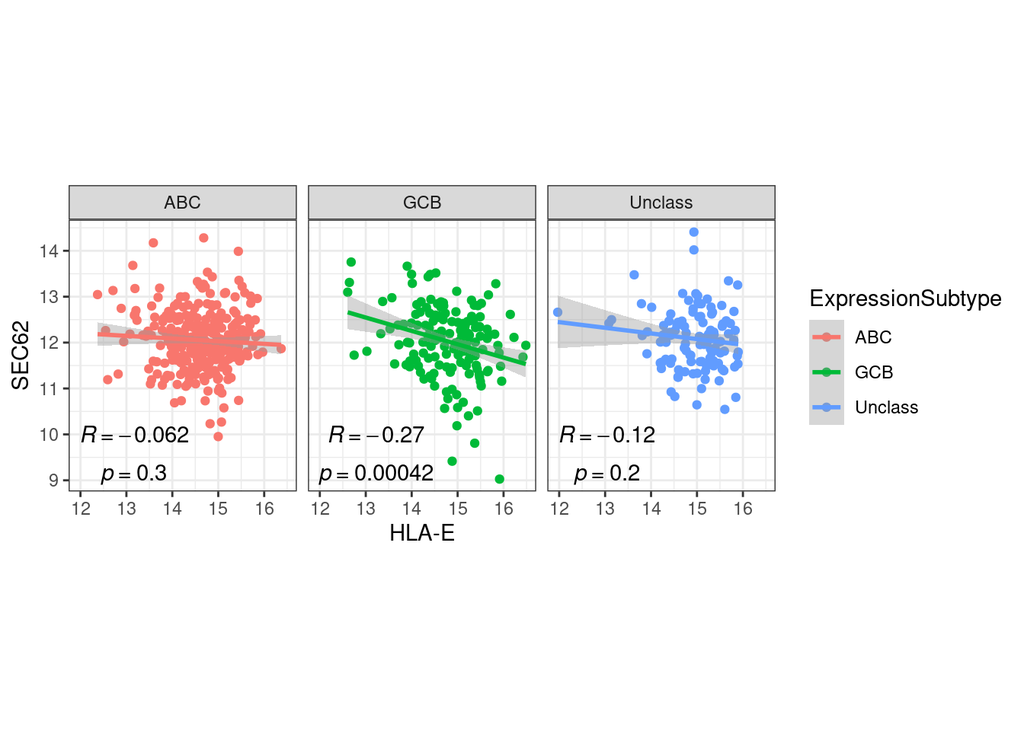

```r
expr %>%
    inner_join(subtypes, by="ID") %>%
    dplyr::filter(Gene %in% c("HLA-E", "SEC62")) %>%
    pivot_wider(names_from=Gene,values_from=Expression) %>%
    ggplot(aes(x = `HLA-E`, y = SEC62, color = ExpressionSubtype)) +
    geom_point() +
    geom_smooth(method="lm") +
    stat_cor(method="pearson",label.sep="\n",label.x.npc="left",label.y.npc="bottom",color = "black",vjust=0.1) +
    facet_wrap(~ExpressionSubtype) +
    coord_fixed() +
    theme_bw()
```

# Plot HLA-E vs SEC62 expression grouped and colored by genetic subtype

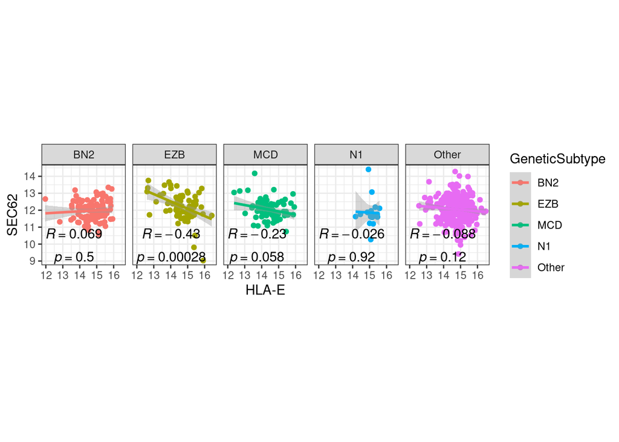

```r
expr %>%
    inner_join(subtypes, by="ID") %>%
    dplyr::filter(Gene %in% c("HLA-E", "SEC62")) %>%
    pivot_wider(names_from=Gene,values_from=Expression) %>%
    ggplot(aes(x = `HLA-E`, y = SEC62, color = GeneticSubtype)) +
    geom_point() +
    geom_smooth(method="lm") +
    stat_cor(method="pearson",label.sep="\n",label.x.npc="left",label.y.npc="bottom",color = "black",vjust=0.1) +
    facet_wrap(~GeneticSubtype, ncol = 5) +
    coord_fixed() +
    theme_bw()
```

# Plot HLA-E and SEC62 expression as a boxplot, grouped and colored by expression subtype

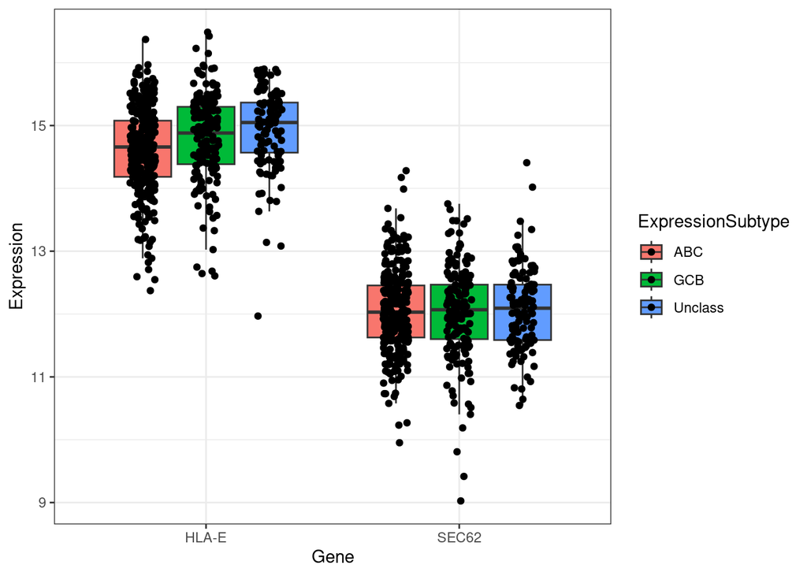

```r
expr %>%
    inner_join(subtypes, by="ID") %>%
    dplyr::filter(Gene %in% c("HLA-E", "SEC62")) %>%
    ggplot(aes(x = Gene, y = Expression, fill = ExpressionSubtype)) +
    geom_boxplot(outlier.shape = NA) +
    geom_point(position = position_jitterdodge(jitter.width = 0.1)) +
    theme_bw()
```

# Plot HLA-E vs SEC62 expression as a boxplot, grouped and colored by genetic subtype

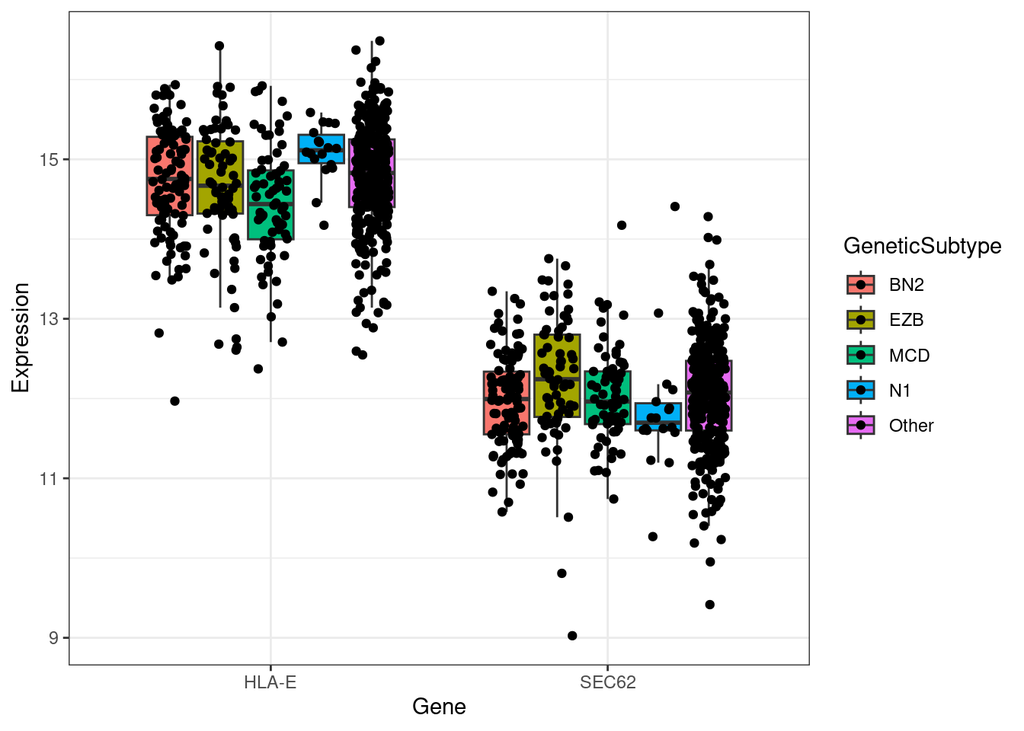

```r
expr %>%
    inner_join(subtypes, by="ID") %>%
    dplyr::filter(Gene %in% c("HLA-E", "SEC62")) %>%
    ggplot(aes(x = Gene, y = Expression, fill = GeneticSubtype)) +
    geom_boxplot(outlier.shape = NA) +
    geom_point(position = position_jitterdodge(jitter.width = 0.1)) +
    theme_bw()
```

# Plot HLA-E vs SEC62 expression as a boxplot, grouped and colored by tumor subtype and SEC62 CNV status

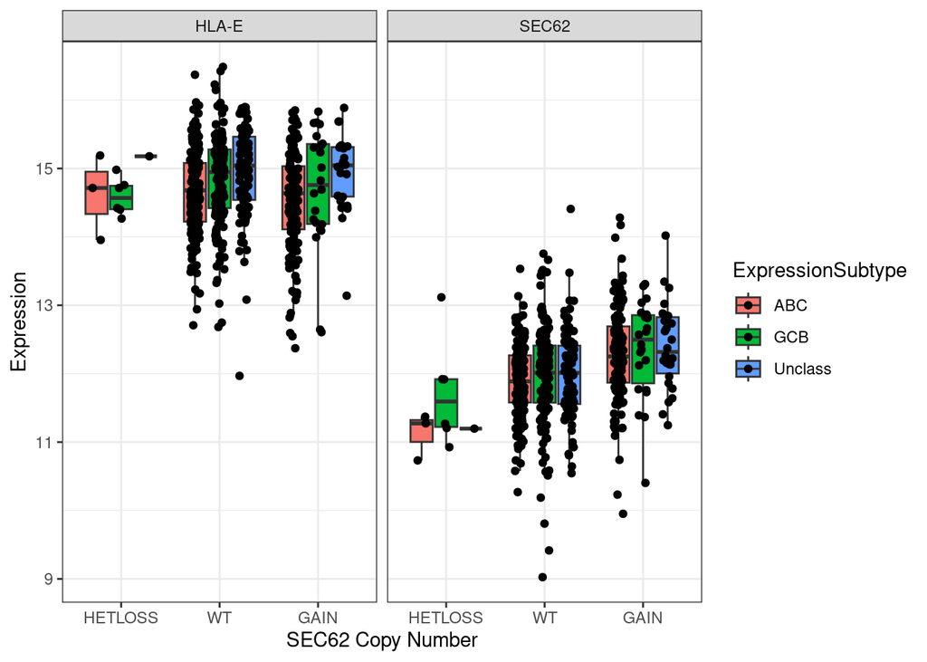

```r
expr %>%
    inner_join(subtypes, by="ID") %>%
    inner_join(sec62_cnv, by="ID") %>%
    dplyr::filter(Gene %in% c("HLA-E", "SEC62")) %>%
    ggplot(aes(x = fct_relevel(SEC62_CopyNumber,c("HETLOSS","WT","GAIN")),
               y = Expression,
               fill = ExpressionSubtype)) +
    geom_boxplot(outlier.shape = NA) +
    geom_point(position = position_jitterdodge(jitter.width = 0.1)) +
    facet_wrap(~Gene) +
    theme_bw() +
    xlab("SEC62 Copy Number")
```

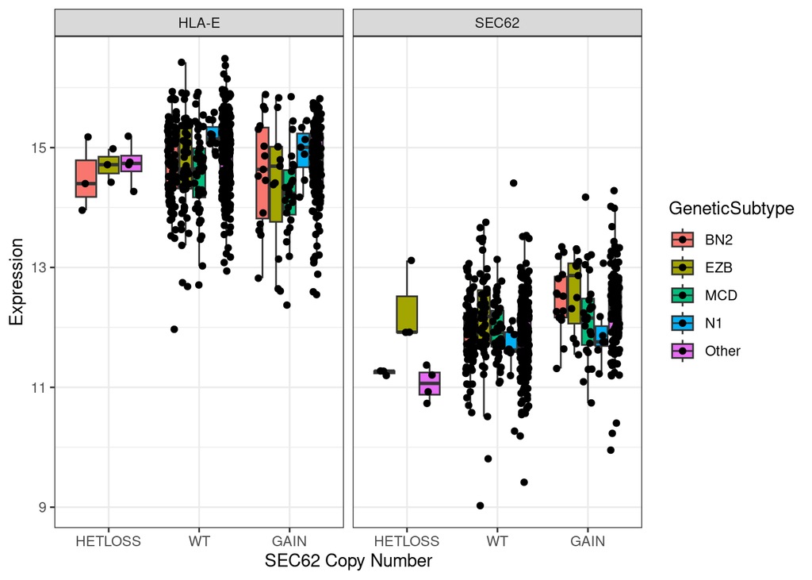

```r
expr %>%
    inner_join(subtypes, by="ID") %>%
    inner_join(sec62_cnv, by="ID") %>%
    dplyr::filter(Gene %in% c("HLA-E", "SEC62")) %>%
    ggplot(aes(x = fct_relevel(SEC62_CopyNumber,c("HETLOSS","WT","GAIN")),
               y = Expression,
               fill = GeneticSubtype)) +
    geom_boxplot(outlier.shape = NA) +
    geom_point(position = position_jitterdodge(jitter.width = 0.1)) +
    facet_wrap(~Gene) +
    theme_bw() +
    xlab("SEC62 Copy Number")
```

# Prepare oncoprint plot with CNV and SNV

## Prepare a character matrix summarizing HLA class I CNVs and SNVs

```r
hla_cnv <- bind_rows(ctsp_gene_cnv,nciccr_gene_cnv,tcga_gene_cnv) %>%
            dplyr::rename("ID" = Subject_Name) %>%
            dplyr::filter(str_detect(Gene_Symbol,"^HLA-") & !str_detect(Gene_Symbol,"^HLA-D")) %>%
            dplyr::select(ID,Gene_Symbol,CopyNubmer_Status) %>%
            mutate(Mutation = case_when(
        !is.na(CopyNubmer_Status) ~ "CNV",
#        !is.na(CopyNubmer_Status) ~ CopyNubmer_Status,
        TRUE ~ NA
        )
    ) %>%
    dplyr::select(-CopyNubmer_Status)

hla_cnv_snv_combined <- bind_rows(hla_cnv,hla_snvs %>% dplyr::rename("Mutation" = HLA_SNV)) %>%
  dplyr::filter(!is.na(Mutation)) %>%
  group_by(ID,Gene_Symbol) %>%
  summarize(Mutation = str_c(Mutation, collapse = ",")) %>%
  ungroup()
```

[output not shown]

```r
cnv.mat <- expand_grid("ID" = meta$`dbGaP submitted subject ID`,
            "Gene_Symbol" = c("HLA-A","HLA-B","HLA-C","HLA-E","HLA-F","HLA-G")
    ) %>%
    left_join(hla_cnv_snv_combined, by=c("ID","Gene_Symbol")) %>%
  left_join(meta, ., by=c("dbGaP submitted subject ID" = "ID")) %>%
  dplyr::select(`dbGaP submitted subject ID`,Mutation,Gene_Symbol) %>%
    dplyr::rename("ID" = `dbGaP submitted subject ID`) %>%
    pivot_wider(names_from=Gene_Symbol,values_from=Mutation) %>%
    column_to_rownames(var="ID") %>%
    as.matrix()
```

## Reformat tumor subtypes

```r
subs <- column_to_rownames(subtypes,var="ID") %>%
    as.data.frame()
```

## Set up oncoprint functions and colors for mutation types

```r
col <- c(SNV = "red", CNV = "blue")
# col <- c(SNV = "red",
#          HETLOSS = "lightblue",
#          HOMDEL = "blue",
#          GAIN = "lightgreen",
#          AMP = "darkgreen"
#          )
alter_fun <- list(
        SNV = function(x, y, w, h) grid.rect(x, y, w*0.9, h*0.9,
            gp = gpar(fill = col["SNV"], col = NA)),
        CNV = function(x, y, w, h) grid.rect(x, y, w*0.9, h*0.4,
            gp = gpar(fill = col["CNV"], col = NA))
        # HETLOSS = function(x, y, w, h) grid.rect(x, y, w*0.9, h*0.4,
        #     gp = gpar(fill = col["HETLOSS"], col = NA)),
        # HOMDEL = function(x, y, w, h) grid.rect(x, y, w*0.9, h*0.4,
        #     gp = gpar(fill = col["HOMDEL"], col = NA)),
        # GAIN = function(x, y, w, h) grid.rect(x, y, w*0.9, h*0.4,
        #     gp = gpar(fill = col["GAIN"], col = NA)),
        # AMP = function(x, y, w, h) grid.rect(x, y, w*0.9, h*0.4,
        #     gp = gpar(fill = col["AMP"], col = NA))

)

get_type_fun <- function(x) strsplit(x, ",")[[1]]

# alter_fun = list(
#     CNV = function(x, y, w, h)
#         grid.rect(x, y, w, h, gp = gpar(fill = "red", col = NA)),
#     SNV = function(x, y, w, h)
#         grid.rect(x, y, w, h, gp = gpar(fill = "blue", col = NA))
# )
#
# col = c(AMP = "red", GAIN = "red4", HETLOSS = "lightblue", HOMDEL = "blue")
```

## Reformat SEC62 and HLA-E expression values along with HLA-A, HLA-B, HLA-C

```r
hla_sec62_expr <- expr %>%
    dplyr::filter(Gene=="HLA-E" | Gene=="SEC62" | Gene=="HLA-A" | Gene=="HLA-B" | Gene=="HLA-C") %>%
    pivot_wider(names_from=Gene,values_from=Expression) %>%
    column_to_rownames(var="ID") %>%
    as.data.frame()
head(hla_sec62_expr)
```

```
            HLA-A  HLA-B  HLA-C  HLA-E  SEC62
CTSP-ACZT  15.729 16.122 14.704 13.867 12.586
CTSP-ACZU  16.172 16.349 15.928 15.145 11.576
CTSP-ACZW  14.382 15.572 15.240 14.390 12.036
CTSP-AD2E  15.601 16.575 15.290 14.107 12.829
CTSP-B02B  15.286 14.920 14.561 14.563 11.528
DLBCL10502 16.264 17.260 16.310 15.190 11.498
```

## Print oncoprint heatmap of SNVs and CNVs for all patients

Omit patients for which there were no CNVs in any HLA class I genes

```
Found NA values in the matrix and treat as no alteration. If `NA` means
no alteration, you can explicitly set it to empty strings like ''. If
`NA` is an alteration type, you should format it to a string like
`'NA'` and define graphics for it.
```

```
All mutation types: CNV, SNV.
```

```
`alter_fun` is assumed vectorizable. If it does not generate correct
plot, please set `alter_fun_is_vectorized = FALSE` in `oncoPrint()`.
```

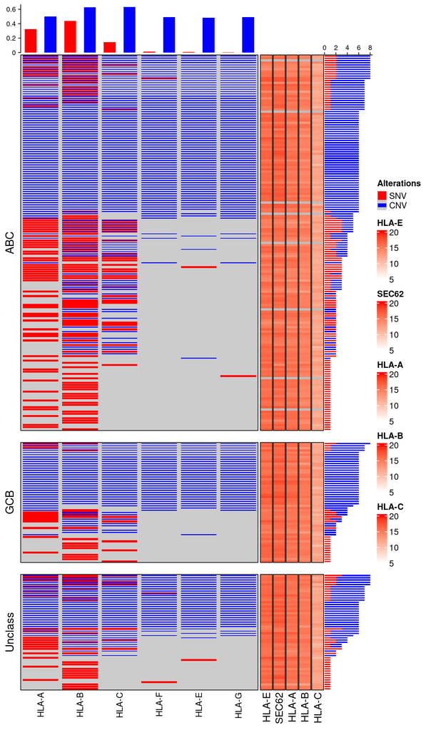

```r
ComplexHeatmap::oncoPrint(cnv.mat,
                        border = TRUE,
                        alter_fun = alter_fun,
                        get_type = get_type_fun,
                        col = col,
                        remove_empty_rows = TRUE,
                        show_column_names = TRUE,
                        show_pct = FALSE,
                        row_split = factor(subs[rownames(cnv.mat),1]),
                        row_gap = unit(5, "mm"),
                        top_annotation = HeatmapAnnotation(
                            column_barplot = anno_oncoprint_barplot(beside=TRUE, show_fraction = TRUE)
                            ),
                        right_annotation = rowAnnotation("HLA-E" = hla_sec62_expr[rownames(cnv.mat),1],
                                                                           "SEC62" = hla_sec62_expr[rownames(cnv.mat),2],
                                                                           "HLA-A" = hla_sec62_expr[rownames(cnv.mat),3],
                                                                           "HLA-B" = hla_sec62_expr[rownames(cnv.mat),4],
                                                                           "HLA-C" = hla_sec62_expr[rownames(cnv.mat),5],
                                                                            rbar = anno_oncoprint_barplot(),
                                                                            border = TRUE,
                                                                            col = list(
                                                                              "HLA-E" = circlize::colorRamp2(c(5, 20),
                                                                                                             c("white","red")),
                                                                              "SEC62" = circlize::colorRamp2(c(5, 20),
                                                                                                             c("white","red")),
                                                                              "HLA-A" = circlize::colorRamp2(c(5, 20),
                                                                                                             c("white","red")),
                                                                              "HLA-B" = circlize::colorRamp2(c(5, 20),
                                                                                                             c("white","red")),
                                                                              "HLA-C" = circlize::colorRamp2(c(5, 20),
                                                                                                             c("white","red"))
                                                                        )
                                                        ),
                        show_row_names = FALSE
)
```

# Repeat but break CNV into each subtype of CNV

## Prepare a character matrix summarizing HLA class I CNVs and SNVs

```r
hla_cnv <- bind_rows(ctsp_gene_cnv,nciccr_gene_cnv,tcga_gene_cnv) %>%
            dplyr::rename("ID" = Subject_Name) %>%
            dplyr::filter(str_detect(Gene_Symbol,"^HLA-") & !str_detect(Gene_Symbol,"^HLA-D")) %>%
            dplyr::select(ID,Gene_Symbol,CopyNubmer_Status) %>%
            mutate(Mutation = case_when(
#        !is.na(CopyNubmer_Status) ~ "CNV",
        !is.na(CopyNubmer_Status) ~ CopyNubmer_Status,
        TRUE ~ NA
        )
    ) %>%
    dplyr::select(-CopyNubmer_Status)

hla_cnv_snv_combined <- bind_rows(hla_cnv,hla_snvs %>% dplyr::rename("Mutation" = HLA_SNV)) %>%
  dplyr::filter(!is.na(Mutation)) %>%
  group_by(ID,Gene_Symbol) %>%
  summarize(Mutation = str_c(Mutation, collapse = ",")) %>%
  ungroup()
```

[output not shown]

```r
cnv.mat <- expand_grid("ID" = meta$`dbGaP submitted subject ID`,
            "Gene_Symbol" = c("HLA-A","HLA-B","HLA-C","HLA-E","HLA-F","HLA-G")
    ) %>%
    left_join(hla_cnv_snv_combined, by=c("ID","Gene_Symbol")) %>%
  left_join(meta, ., by=c("dbGaP submitted subject ID" = "ID")) %>%
  dplyr::select(`dbGaP submitted subject ID`,Mutation,Gene_Symbol) %>%
    dplyr::rename("ID" = `dbGaP submitted subject ID`) %>%
    pivot_wider(names_from=Gene_Symbol,values_from=Mutation) %>%
    column_to_rownames(var="ID") %>%
    as.matrix()
```

## Summarize HLA gene CNV counts by expression subtype

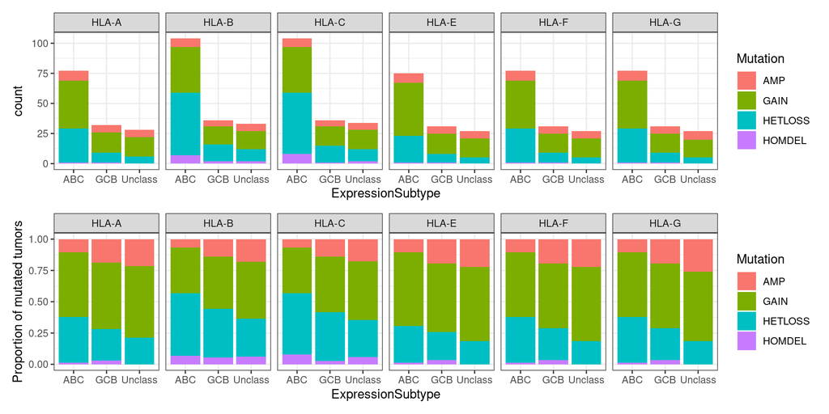

```r
p1 <- expand_grid("ID" = meta$`dbGaP submitted subject ID`,
            "Gene_Symbol" = c("HLA-A","HLA-B","HLA-C","HLA-E","HLA-F","HLA-G")
) %>%
    left_join(hla_cnv, by=c("ID","Gene_Symbol")) %>%
    left_join(meta, ., by=c("dbGaP submitted subject ID" = "ID")) %>%
    dplyr::select(`dbGaP submitted subject ID`,Mutation,Gene_Symbol) %>%
    dplyr::rename("ID" = `dbGaP submitted subject ID`) %>%
    left_join(subtypes,by="ID") %>%
    dplyr::filter(!is.na(Mutation)) %>%
    ggplot(aes(x = ExpressionSubtype, fill = Mutation)) +
    geom_bar() +
    facet_wrap(~Gene_Symbol, ncol = 6) +
    theme_bw()

p2 <- expand_grid("ID" = meta$`dbGaP submitted subject ID`,
            "Gene_Symbol" = c("HLA-A","HLA-B","HLA-C","HLA-E","HLA-F","HLA-G")
) %>%
    left_join(hla_cnv, by=c("ID","Gene_Symbol")) %>%
    left_join(meta, ., by=c("dbGaP submitted subject ID" = "ID")) %>%
    dplyr::select(`dbGaP submitted subject ID`,Mutation,Gene_Symbol) %>%
    dplyr::rename("ID" = `dbGaP submitted subject ID`) %>%
    left_join(subtypes,by="ID") %>%
    dplyr::filter(!is.na(Mutation)) %>%
    ggplot(aes(x = ExpressionSubtype, fill = Mutation)) +
    geom_bar(position = "fill") +
    facet_wrap(~Gene_Symbol, ncol = 6) +
    ylab("Proportion of mutated tumors") +
    theme_bw()

p1 / p2
```

### Represent proportions of HET and HOM loss as a heatmap

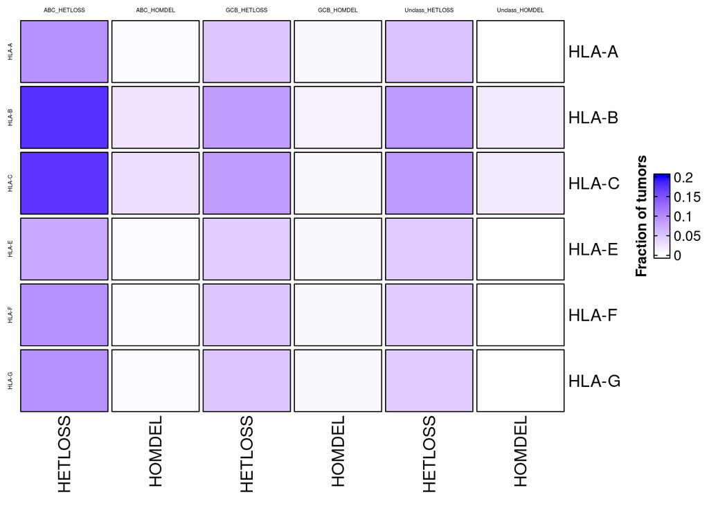

```r
cnvloss_mat <- expand_grid("ID" = meta$`dbGaP submitted subject ID`,
            "Gene_Symbol" = c("HLA-A","HLA-B","HLA-C","HLA-E","HLA-F","HLA-G")
) %>%
    left_join(hla_cnv_snv_combined, by=c("ID","Gene_Symbol")) %>%
    left_join(meta, ., by=c("dbGaP submitted subject ID" = "ID")) %>%
    dplyr::select(`dbGaP submitted subject ID`,Mutation,Gene_Symbol) %>%
    dplyr::rename("ID" = `dbGaP submitted subject ID`) %>%
    left_join(subtypes,by="ID") %>%
    mutate(CNV = case_when(
        str_detect(Mutation,"LOSS") ~ "HETLOSS",
        str_detect(Mutation,"DEL") ~ "HOMDEL",
        TRUE ~ NA
    )) %>%
    dplyr::select(-Mutation) %>%
    group_by(CNV,Gene_Symbol,ExpressionSubtype) %>%
    summarize(n = dplyr::n()) %>%
    ungroup() %>%
    group_by(Gene_Symbol,ExpressionSubtype) %>%
    mutate(Freq = n / sum(n)) %>%
    dplyr::filter(!is.na(CNV)) %>%
    dplyr::select(-n) %>%
    pivot_wider(names_from=c(ExpressionSubtype,CNV),values_from=Freq) %>%
    column_to_rownames(var="Gene_Symbol") %>%
    as.data.frame() %>%
    as.matrix()
ComplexHeatmap::Heatmap(cnvloss_mat,
                        cluster_rows = FALSE,
                        cluster_columns = FALSE,
                        column_split = factor(colnames(cnvloss_mat)),
                        column_title_gp = gpar(fontsize = 4),
                        row_split = factor(rownames(cnvloss_mat)),
                        row_title_gp = gpar(fontsize = 4),
                        column_labels = str_replace_all(colnames(cnvloss_mat),".+_",""),
                        name = "Fraction of tumors",
                        heatmap_legend_param = list(title_position = "leftcenter-rot",
                                                    border = TRUE),
                        na_col = "white",
                        border = TRUE,
                        col = circlize::colorRamp2(c(0,0.2),c("white","blue"))
                        )
```

## Summarize HLA gene CNV counts by genetic subtype

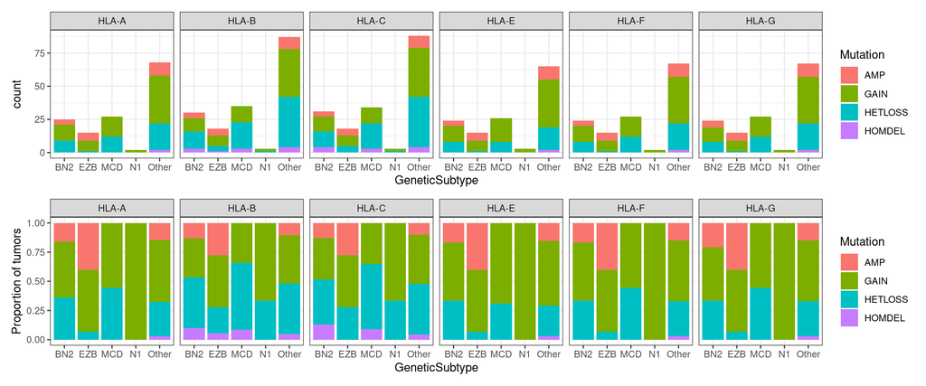

```r
p3 <- expand_grid("ID" = meta$`dbGaP submitted subject ID`,
            "Gene_Symbol" = c("HLA-A","HLA-B","HLA-C","HLA-E","HLA-F","HLA-G")
) %>%
    left_join(hla_cnv, by=c("ID","Gene_Symbol")) %>%
    left_join(meta, ., by=c("dbGaP submitted subject ID" = "ID")) %>%
    dplyr::select(`dbGaP submitted subject ID`,Mutation,Gene_Symbol) %>%
    dplyr::rename("ID" = `dbGaP submitted subject ID`) %>%
    left_join(subtypes,by="ID") %>%
    dplyr::filter(!is.na(Mutation)) %>%
    ggplot(aes(x = GeneticSubtype, fill = Mutation)) +
    geom_bar() +
    facet_wrap(~Gene_Symbol, ncol = 6) +
    theme_bw()

p4 <- expand_grid("ID" = meta$`dbGaP submitted subject ID`,
            "Gene_Symbol" = c("HLA-A","HLA-B","HLA-C","HLA-E","HLA-F","HLA-G")
) %>%
    left_join(hla_cnv, by=c("ID","Gene_Symbol")) %>%
    left_join(meta, ., by=c("dbGaP submitted subject ID" = "ID")) %>%
    dplyr::select(`dbGaP submitted subject ID`,Mutation,Gene_Symbol) %>%
    dplyr::rename("ID" = `dbGaP submitted subject ID`) %>%
    left_join(subtypes,by="ID") %>%
    dplyr::filter(!is.na(Mutation)) %>%
    ggplot(aes(x = GeneticSubtype, fill = Mutation)) +
    geom_bar(position = "fill") +
    facet_wrap(~Gene_Symbol, ncol = 6) +
    ylab("Proportion of tumors") +
    theme_bw()

p3 / p4
```

## Reformat tumor subtypes

```r
subs <- column_to_rownames(subtypes,var="ID") %>%
    as.data.frame()
```

## Set up oncoprint functions and colors for mutation types

```r
#col <- c(SNV = "red", CNV = "blue")
col <- c(SNV = "red",
         HETLOSS = "lightblue",
         HOMDEL = "blue",
         GAIN = "lightgreen",
         AMP = "darkgreen"
         )
alter_fun <- list(
        SNV = function(x, y, w, h) grid.rect(x, y, w*0.9, h*0.9,
            gp = gpar(fill = col["SNV"], col = NA)),
#        CNV = function(x, y, w, h) grid.rect(x, y, w*0.9, h*0.4,
#            gp = gpar(fill = col["CNV"], col = NA)),
        HETLOSS = function(x, y, w, h) grid.rect(x, y, w*0.9, h*0.4,
            gp = gpar(fill = col["HETLOSS"], col = NA)),
        HOMDEL = function(x, y, w, h) grid.rect(x, y, w*0.9, h*0.4,
            gp = gpar(fill = col["HOMDEL"], col = NA)),
        GAIN = function(x, y, w, h) grid.rect(x, y, w*0.9, h*0.4,
            gp = gpar(fill = col["GAIN"], col = NA)),
        AMP = function(x, y, w, h) grid.rect(x, y, w*0.9, h*0.4,
            gp = gpar(fill = col["AMP"], col = NA))

)

get_type_fun <- function(x) strsplit(x, ",")[[1]]

# alter_fun = list(
#     CNV = function(x, y, w, h)
#         grid.rect(x, y, w, h, gp = gpar(fill = "red", col = NA)),
#     SNV = function(x, y, w, h)
#         grid.rect(x, y, w, h, gp = gpar(fill = "blue", col = NA))
# )
#
# col = c(AMP = "red", GAIN = "red4", HETLOSS = "lightblue", HOMDEL = "blue")
```

## Print oncoprint heatmap of CNV types for all patients

Omit patients for which there were no CNVs in any HLA class I genes

```
Found NA values in the matrix and treat as no alteration. If `NA` means
no alteration, you can explicitly set it to empty strings like ''. If
`NA` is an alteration type, you should format it to a string like
`'NA'` and define graphics for it.
```

```
All mutation types: AMP, HETLOSS, GAIN, SNV, HOMDEL.
```

```
`alter_fun` is assumed vectorizable. If it does not generate correct
plot, please set `alter_fun_is_vectorized = FALSE` in `oncoPrint()`.
```

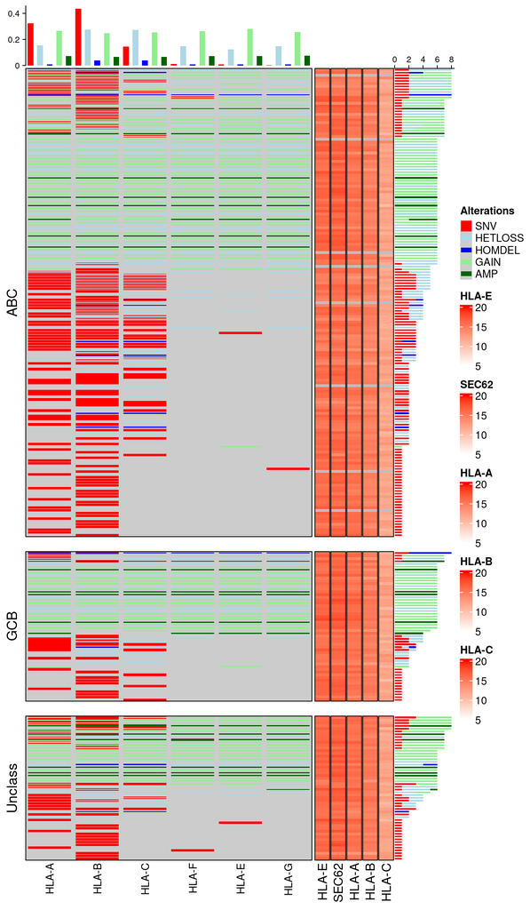

```r
ComplexHeatmap::oncoPrint(cnv.mat,
                        border = TRUE,
                        alter_fun = alter_fun,
                        get_type = get_type_fun,
                        col = col,
                        remove_empty_rows = TRUE,
                        show_column_names = TRUE,
                        show_pct = FALSE,
                        row_split = factor(subs[rownames(cnv.mat),1]),
                        row_gap = unit(5, "mm"),
                        top_annotation = HeatmapAnnotation(
                            column_barplot = anno_oncoprint_barplot(beside=TRUE, show_fraction = TRUE)
                            ),
                        right_annotation = rowAnnotation("HLA-E" = hla_sec62_expr[rownames(cnv.mat),1],
                                                                           "SEC62" = hla_sec62_expr[rownames(cnv.mat),2],
                                                                           "HLA-A" = hla_sec62_expr[rownames(cnv.mat),3],
                                                                           "HLA-B" = hla_sec62_expr[rownames(cnv.mat),4],
                                                                           "HLA-C" = hla_sec62_expr[rownames(cnv.mat),5],
                                                                            rbar = anno_oncoprint_barplot(),
                                                                            border = TRUE,
                                                                            col = list(
                                                                              "HLA-E" = circlize::colorRamp2(c(5, 20),
                                                                                                             c("white","red")),
                                                                              "SEC62" = circlize::colorRamp2(c(5, 20),
                                                                                                             c("white","red")),
                                                                              "HLA-A" = circlize::colorRamp2(c(5, 20),
                                                                                                             c("white","red")),
                                                                              "HLA-B" = circlize::colorRamp2(c(5, 20),
                                                                                                             c("white","red")),
                                                                              "HLA-C" = circlize::colorRamp2(c(5, 20),
                                                                                                             c("white","red"))
                                                                        )
                                                        ),
                        show_row_names = FALSE
)
```

# Repeat but drop the GAIN and AMP status

## Prepare a character matrix summarizing HLA class I CNVs and SNVs

```r
hla_cnv <- bind_rows(ctsp_gene_cnv,nciccr_gene_cnv,tcga_gene_cnv) %>%
            dplyr::rename("ID" = Subject_Name) %>%
            dplyr::filter(str_detect(Gene_Symbol,"^HLA-") & !str_detect(Gene_Symbol,"^HLA-D")) %>%
            dplyr::select(ID,Gene_Symbol,CopyNubmer_Status) %>%
      dplyr::filter(CopyNubmer_Status != "GAIN" & CopyNubmer_Status != "AMP") %>%
            mutate(Mutation = case_when(
#        !is.na(CopyNubmer_Status) ~ "CNV",
        !is.na(CopyNubmer_Status) ~ CopyNubmer_Status,
        TRUE ~ NA
        )
    ) %>%
    dplyr::select(-CopyNubmer_Status)

hla_cnv_snv_combined <- bind_rows(hla_cnv,hla_snvs %>% dplyr::rename("Mutation" = HLA_SNV)) %>%
  dplyr::filter(!is.na(Mutation)) %>%
  group_by(ID,Gene_Symbol) %>%
  summarize(Mutation = str_c(Mutation, collapse = ",")) %>%
  ungroup()
```

[output not shown]

```r
cnv.mat <- expand_grid("ID" = meta$`dbGaP submitted subject ID`,
            "Gene_Symbol" = c("HLA-A","HLA-B","HLA-C","HLA-E","HLA-F","HLA-G")
    ) %>%
    left_join(hla_cnv_snv_combined, by=c("ID","Gene_Symbol")) %>%
  left_join(meta, ., by=c("dbGaP submitted subject ID" = "ID")) %>%
  dplyr::select(`dbGaP submitted subject ID`,Mutation,Gene_Symbol) %>%
    dplyr::rename("ID" = `dbGaP submitted subject ID`) %>%
    pivot_wider(names_from=Gene_Symbol,values_from=Mutation) %>%
    column_to_rownames(var="ID") %>%
    as.matrix()
```

## Reformat tumor subtypes

```r
subs <- column_to_rownames(subtypes,var="ID") %>%
    as.data.frame()
```

## Set up oncoprint functions and colors for mutation types

```r
#col <- c(SNV = "red", CNV = "blue")
col <- c(SNV = "purple",
         HETLOSS = "dodgerblue",
         HOMDEL = "dodgerblue4"
#         GAIN = "lightgreen",
#         AMP = "darkgreen"
         )
alter_fun <- list(
        SNV = function(x, y, w, h) grid.rect(x, y, w*0.9, h*0.9,
            gp = gpar(fill = col["SNV"], col = NA)),
#        CNV = function(x, y, w, h) grid.rect(x, y, w*0.9, h*0.4,
#            gp = gpar(fill = col["CNV"], col = NA)),
        HETLOSS = function(x, y, w, h) grid.rect(x, y, w*0.9, h*0.4,
            gp = gpar(fill = col["HETLOSS"], col = NA)),
        HOMDEL = function(x, y, w, h) grid.rect(x, y, w*0.9, h*0.4,
            gp = gpar(fill = col["HOMDEL"], col = NA))
#        GAIN = function(x, y, w, h) grid.rect(x, y, w*0.9, h*0.4,
#            gp = gpar(fill = col["GAIN"], col = NA)),
#        AMP = function(x, y, w, h) grid.rect(x, y, w*0.9, h*0.4,
#            gp = gpar(fill = col["AMP"], col = NA))

)

get_type_fun <- function(x) strsplit(x, ",")[[1]]

# alter_fun = list(
#     CNV = function(x, y, w, h)
#         grid.rect(x, y, w, h, gp = gpar(fill = "red", col = NA)),
#     SNV = function(x, y, w, h)
#         grid.rect(x, y, w, h, gp = gpar(fill = "blue", col = NA))
# )
#
# col = c(AMP = "red", GAIN = "red4", HETLOSS = "lightblue", HOMDEL = "blue")
```

## Print oncoprint heatmap of CNV types for all patients

Omit patients for which there were no CNVs in any HLA class I genes

```
Found NA values in the matrix and treat as no alteration. If `NA` means
no alteration, you can explicitly set it to empty strings like ''. If
`NA` is an alteration type, you should format it to a string like
`'NA'` and define graphics for it.
```

```
All mutation types: HETLOSS, SNV, HOMDEL.
```

```
`alter_fun` is assumed vectorizable. If it does not generate correct
plot, please set `alter_fun_is_vectorized = FALSE` in `oncoPrint()`.
```

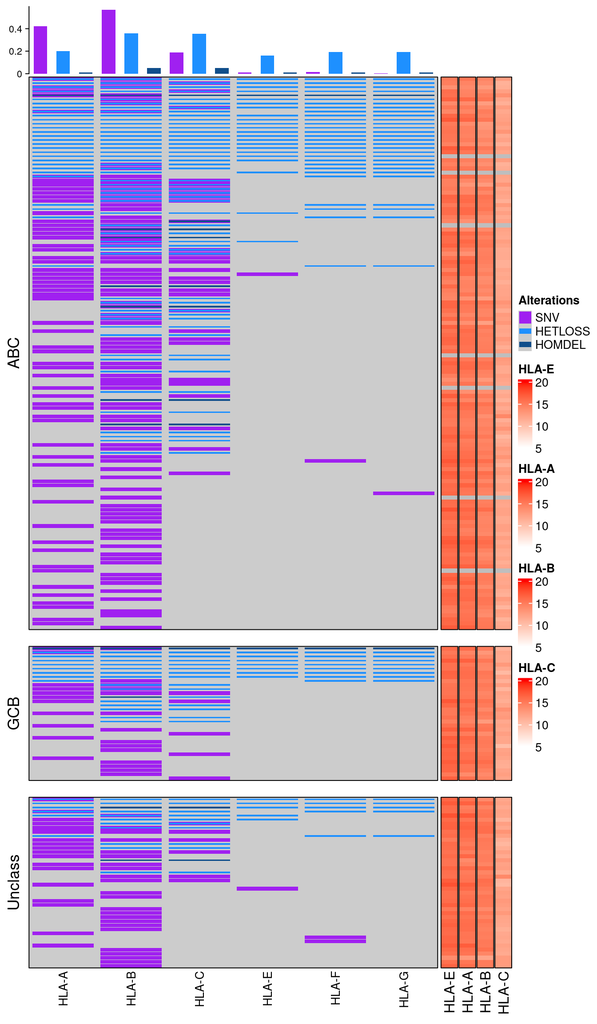

```r
ComplexHeatmap::oncoPrint(cnv.mat,
                        border = TRUE,
                        alter_fun = alter_fun,
                        get_type = get_type_fun,
                        col = col,
                        remove_empty_rows = TRUE,
                        show_column_names = TRUE,
                        column_order = c("HLA-A","HLA-B","HLA-C","HLA-E","HLA-F","HLA-G"),
                        show_pct = FALSE,
                        row_split = factor(subs[rownames(cnv.mat),1]),
                        row_gap = unit(5, "mm"),
                        top_annotation = HeatmapAnnotation(
                            column_barplot = anno_oncoprint_barplot(beside=TRUE, show_fraction = TRUE)
                            ),
                        right_annotation = rowAnnotation("HLA-E" = hla_sec62_expr[rownames(cnv.mat),1],
                                                                           "HLA-A" = hla_sec62_expr[rownames(cnv.mat),3],
                                                                           "HLA-B" = hla_sec62_expr[rownames(cnv.mat),4],
                                                                           "HLA-C" = hla_sec62_expr[rownames(cnv.mat),5],
                                                                            #rbar = anno_oncoprint_barplot(),
                                                                            border = TRUE,
                                                                            col = list(
                                                                              "HLA-E" = circlize::colorRamp2(c(5, 20),
                                                                                                             c("white","red")),
                                                                              "HLA-A" = circlize::colorRamp2(c(5, 20),
                                                                                                             c("white","red")),
                                                                              "HLA-B" = circlize::colorRamp2(c(5, 20),
                                                                                                             c("white","red")),
                                                                              "HLA-C" = circlize::colorRamp2(c(5, 20),
                                                                                                             c("white","red"))
                                                                        )
                                                        ),
                        show_row_names = FALSE
)
```

[output not shown]

[output not shown]

[output not shown]